# Przykład projektu

Tomasz Przechlewski

Powiślańska Szkoła Wyższa (Kwidzyn/Poland)  
t.plata-przechlewski@psw.kwidzyn.edu.pl

21/2/2026

## Oczekiwany zakres analizy:-)

Praca ma zawierać następujące elementy:

- Określenie co jest analizowane + podanie źródła skąd dane zostały pobrane
- Analiza jednej zmiennej np. częstość występowania otyłości w Europie

  – histogram i/lub wykres pudełkowy lub jakiś inny,

  – średnia, mediana, kwartyle,

  – wariancja, odchylenie standardowe, odchylenie ćwiartkowe

  – współczynnik skośności
- Analiza dwu zmiennych, np. częstość występowania cukrzycy a występowanie otyłości w Europie albo `number of neonatal deaths` vs `number of medical doctors`.

  – wykres (korelogram)

  – model regresji liniowej, interpretacja parametrów(u) modelu

  – współczynnik determinacji $R^2$, ocena istotności parametrów
- Analiza szeregu czasowego, np liczby zgonów na szpiczaka plazocytowego w Polsce

  – wykres

  – model trendu liniowego

  – współczynnik determinacji $R^2$, ocena istotności parametrów

  – obliczyć średnie tempo zmian

## Przykład

Proszę nie kopiować literalnie, poniższe ma stanowić inspirację :-)

### Dane

Wykorzystano następujące zbiory danych

- Otyłość wśród dorosłych, BMI ≥ 30, częstość występowania (surowe oszacowanie) (%) (*Obesity among adults, BMI >= 30, prevalence (crude estimate) (%)*) https://www.who.int/data/gho/data/indicators/indicator-details/GHO/prevalence-of-obesity-among-adults-bmi-=-30-(crude-estimate)-(-)
- Standaryzowana względem wieku częstość występowania cukrzycy (%) (*Age standardized prevalenc of diabets (%)*) https://www.who.int/data/gho/data/indicators/indicator-details/GHO/prevalence-of-diabetes-age-standardized
- Liczba zmarłych z powodu chłoniaków oraz szpiczka mnogiego w Polsce w latach 1959–2022 https://platform.who.int/mortality/themes/theme-details/topics/indicator-groups/indicator-group-details/MDB/lymphomas-multiple-myeloma

### Otyłość wśród dorosłych w Europie w latach 2000 oraz 2022

W tabeli zestawiono, a na wykresie przedstawiono przeciętny poziom zjawiska, jego rozproszenie oraz skośność w latach 2000 i 2022.

| year | mean | median | q1 | q3 | variance | sd | iqr | skweness |
| --- | --- | --- | --- | --- | --- | --- | --- | --- |
| 2000 | 16.58994 | 16.59954 | 13.13881 | 19.73004 | 15.51547 | 3.938968 | 6.591226 | 0.1944353 |
| 2022 | 25.63361 | 25.84998 | 20.99145 | 29.93067 | 40.16141 | 6.337303 | 8.939220 | -0.0289372 |

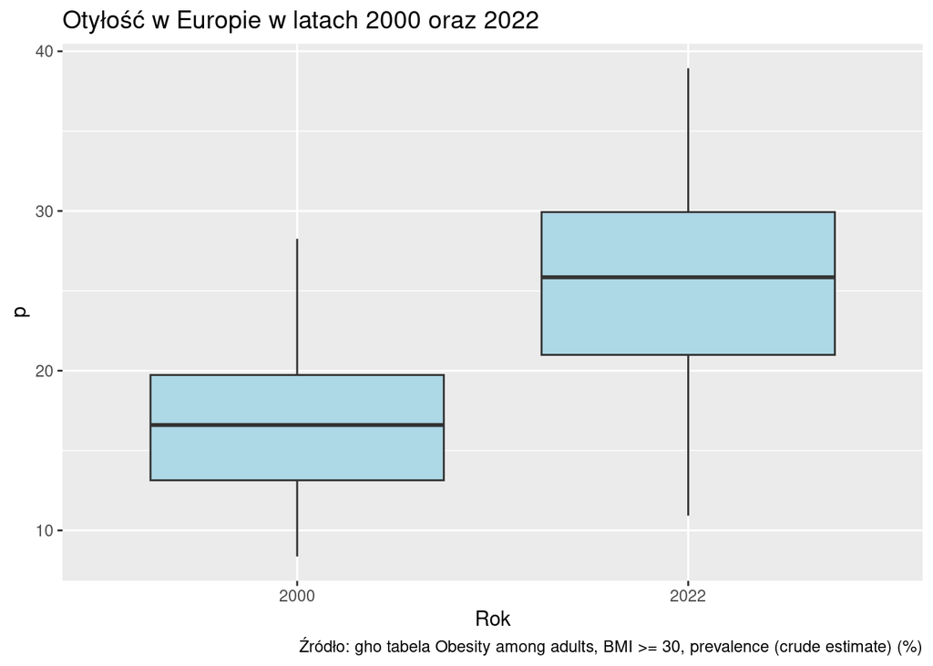

W porównaniu do pierwszego okresu, w drugim okresie obserwuje się wyraźny wzrost poziomu otyłości, co widoczne jest w wyższej medianie i średniej. Jednocześnie zwiększone rozproszenie wskazuje, że populacja stała się bardziej niejednorodna — różnice między krajami o najniższych i najwyższych wartościach otyłości uległy pogłębieniu.

## Wpływ otyłości na występowanie cukrzycy w modelu regresji liniowej

Zależność pomiędzy otyłością na występowanie cukrzycy przedstawiono na rysunku

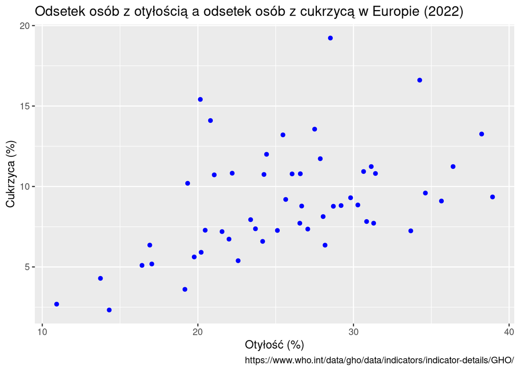

Hipoteza badawcza: istnieje zależność między otyłością a częstością występowania cukrzycy

Do weryfikacji hipotezy wykorzystujemy dane nt. otyłości oraz cukrzycy w Europie w 2022 roku

```
##
## Call:
## lm(formula = d ~ o, data = oc.eur)
##
## Residuals:
##     Min      1Q  Median      3Q     Max
## -3.8758 -1.7902 -0.9225  1.5681  9.4628
##
## Coefficients:
##             Estimate Std. Error t value Pr(>|t|)
## (Intercept)  2.27917    1.73995    1.31 0.196214
## o            0.26243    0.06593    3.98 0.000223 ***
## ---
## Signif. codes:  0 '***' 0.001 '**' 0.01 '*' 0.05 '.' 0.1 ' ' 1
##
## Residual standard error: 2.984 on 50 degrees of freedom
## Multiple R-squared:  0.2406, Adjusted R-squared:  0.2254
## F-statistic: 15.84 on 1 and 50 DF,  p-value: 0.0002226
```

Hipoteza badawcza została potwierdzona: jeżeli odsetek osób z otyłością wzrośnie o 1% to odsetek osób z cukrzycą przeciętnie wzrośnie o 0,26%; wartość ta jest istotna statystycznie ($p=0.0002$). Wielkość współczynnika determinacji $R^2 = 24$% oznacza, że 24% zmienności odsetka osób z cukrzycą jest wyjaśniane przez model (czyli nie za dużo).

## Analiza trendu liniowego liczby zgonów z powodu chłoniaka oraz szpiczaka mnogiego w Polsce

Liczbę zgonów z powodu chłoniaka oraz szpiczaka mnogiego w Polsce w latach 1959–2022 według płci zmarłego przedstawiono na wykresie.

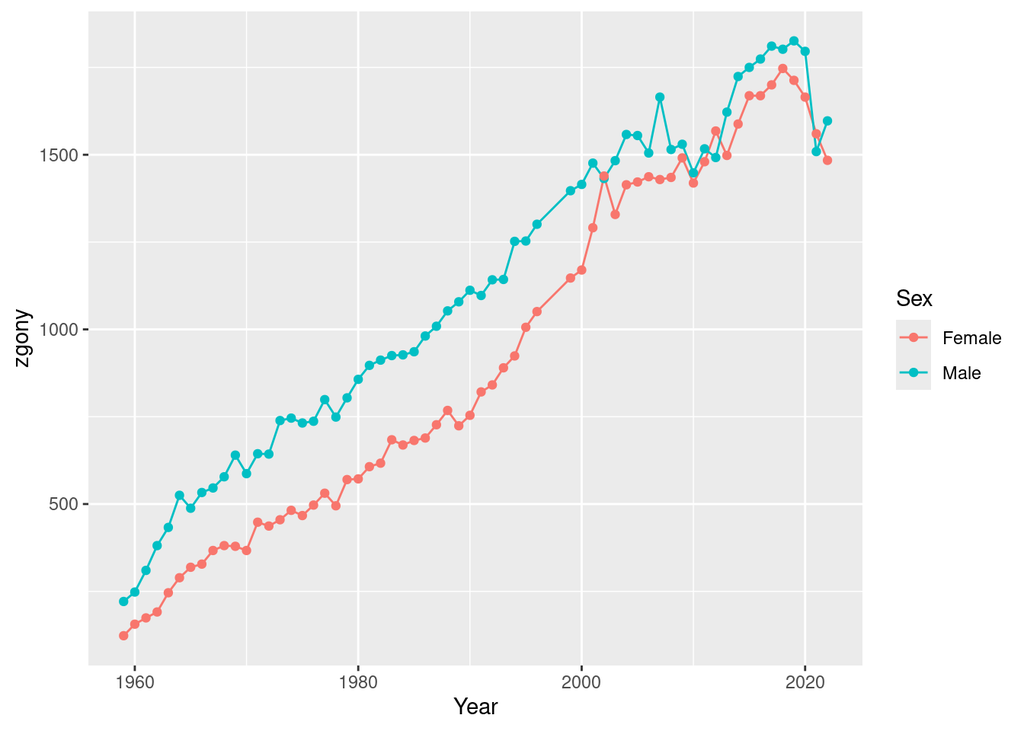

Moża zaobserwować wyrażny trend liniowy do okołu roku 2018, w którym to roku nastąpiła wyraźne odwrócenie tendencji i spadek. Z powodu obu chorób umierało więcej mężczyzn niż kobiet.

Oszacowano także model trendu liniowego liczby zgonów łącznie (kobiety + mężczyźni) z powodu chłoniaka oraz szpiczaka mnogiego w Polsce w latach 1959–2022

```
##
## Call:
## lm(formula = zgony ~ trend, data = m.pl.bothsexes)
##
## Residuals:
##     Min      1Q  Median      3Q     Max
## -543.54  -89.11  -19.10   93.45  304.67
##
## Coefficients:
##             Estimate Std. Error t value             Pr(>|t|)
## (Intercept) 379.3605    41.5248   9.136    0.000000000000584 ***
## trend        17.6368     0.3884  45.413 < 0.0000000000000002 ***
## ---
## Signif. codes:  0 '***' 0.001 '**' 0.01 '*' 0.05 '.' 0.1 ' ' 1
##
## Residual standard error: 164.1 on 60 degrees of freedom
## Multiple R-squared:  0.9717, Adjusted R-squared:  0.9713
## F-statistic:  2062 on 1 and 60 DF,  p-value: < 0.00000000000000022
```

W latach 1959–2022 przeciętny roczny wzrost liczby zgonów wynosił około 17,6 osób; wielkość ta jest istotna statystycznie. Wartość współczynnika determinacji jest wysoka bo wynosi 97%.

Średnie tempo zmian liczby zgonów łącznie w latach 1959-2022 wynosiło 3.7%, tj. przeciętnie w tym okresie liczba zgonów ogółem rośnie o 3.7%.